# PROJET MACHINE LEARNING

Marlène CHEVALIER et Olga SILVA

Juin 2020

# 1 Sujet d’étude : succès d’une campagne marketing

L’analyse porte sur une campagne marketing conduite auprès d’un ensemble de clients résidant en France. Sur chaque client, le résultat de la campagne est mesurée par sa “réussite (success)” ou son “échec (failure)”.

**L’objectif du projet consiste à prédire le succès de la campagne marketing en fonction des caractéristiques des clients**

## 1.1 Jeu de données

Pour cela, nous disposons de 2 fichiers qui, pour chaque ligne d’un ﬁchier, décrit un client.

- le fichier d’apprentissage/d’entainement (10 000 clients et 12 variables) : **projet-app-13-learn.csv**
- le fichier test (10 000 clients et 11 variables) : **projet-app-13-test.csv**

Les variables caractérisant chaque client sont les suivantes :

- **age** : âge du client
- **sex** : genre du client
- **f_name** : prénom du client
- **last name** : nom du client
- **commune** : nom de la commune de résidence du client  
  (Lyon, Paris et Marseille sont découpées en arrondissements et que le nom de commune est alors celui de la ville suivi de l’indication d’arrondissement)
- **insee code** : code insee de la commune de résidence
- **city type** : type de la commune de résidence
- **department** : numéro du département de résidence
- **reg** : code de la région de résidence
- **catégorie** : code de la catégorie socio-professionnelle du client
- **revenu** : salaire mensuel en équivalent temps plein
- **cible** : résultat de la campagne codé par “success” pour un résultat considéré comme positif et “failure” dans le cas contraire. Cette variable est absente du fichier test.

## 1.2 Données annexes

Des informations annexes peuvent être utilisées pour cette analyse :

- la **table des catégories socio-professionnelles** associe le code et le nom de chaque catégorie
- le fichier **cities-gps.csv** contient les coordonnées géographiques des villes de métropole, identifiées par leur code insee
- le fichier **cities-population.csv** contient la population de chaque ville de métropole
- le fichier **departments.csv** contient l’association entre le numéro de département et son nom, ainsi que la région dans laquelle chaque département est situé
- le fichier **regions.csv** contient l’association entre le numéro de région et son nom

**Contenu du Rapport (A garder pour memoire - et supprimer avant transmission du projet )**

1. Analyse exploratoire minimale des données (statistiques univariées, dépendances, etc.) ;
2. Justification du modèles prédictif choisi ;
3. Description précise de la chaîne de traitement : prétraitements éventuels, ajustement des modèles, choix du modèle, évaluation de ses performances attendues (le rapport doit impérativement contenir un tableau indiquant la qualité numérique attendue pour les prévisions sur le fichier test) ;
4. Analyse de l’importance des variables : cela peut être fait avant l’ajustement des modèles, pendant celui-ci ou après le choix du modèle final. Dans tous les cas, le rapport doit discuter de l’opportunité de construire des modèles sur une partie seulement des variables. Si c’est le cas, les prévisions finales et les performances attendues doivent concerner les modèles n’utilisant que les variables pertinentes ;
5. Interprétation du modèle retenu : si cela est possible, une interprétation de la façon dont les décisions du modèle retenu sont prises fournira un complément très important au reste de l’analyse.

# 2 Préparation des données

## 2.1 Chargement des données et préparation des variables

**Retraitements nécessaires :**

- Nous allons renommer la variable catégorie, pour enlever l’accent : *catégorie* devient *categorie*
- Certaines variables numériques sont à interpréter comme des codes, nous les convertissons en facteur : *reg* et *categorie*.
- Nous convertissons la variable cible en variable logique : “failure” devient FALSE et “success” devient TRUE

**Compléter avec les données géographiques :**

Nous ajoutons les coordonnées géographiques et la population aux jeux de données d’entrainement et de test.

## 2.2 Traitement des données manquantes

### 2.2.1 Recencement des données manquantes

**Jeu d’appprentisage**

Dans le jeu d’apprentissage, seule la variable “revenue” est manquante pour 5320 valeurs, soit 53% de valeurs manquantes.

Le graphique suivant confirme cette observation :

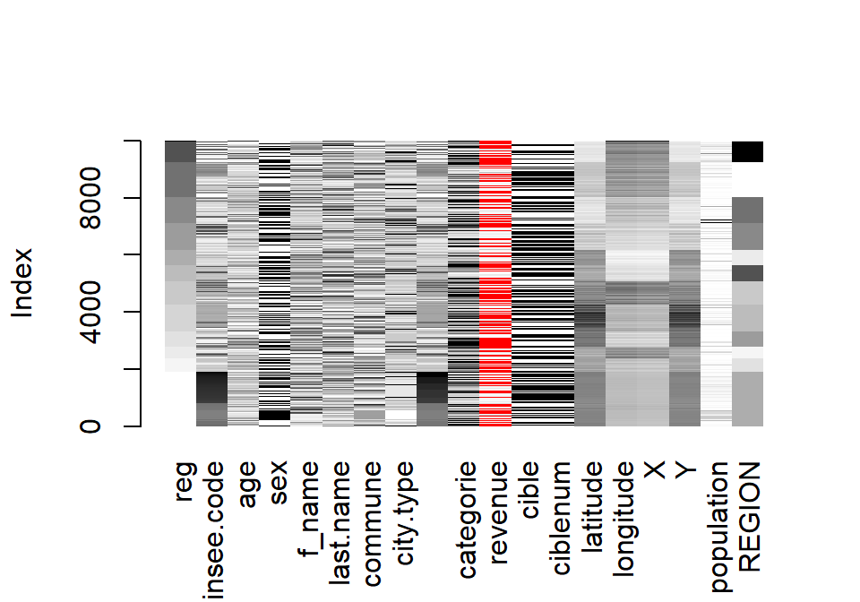

**Jeu de test**

Dans le jeu test, seule la variable “revenue” est manquante pour 5175 valeurs, soit 52% de valeurs manquantes.

### 2.2.2 Résultat de campagne et revenus manquants

Regardons s’il y a un lien entre le résultat de la campagne et les revenus manquants.

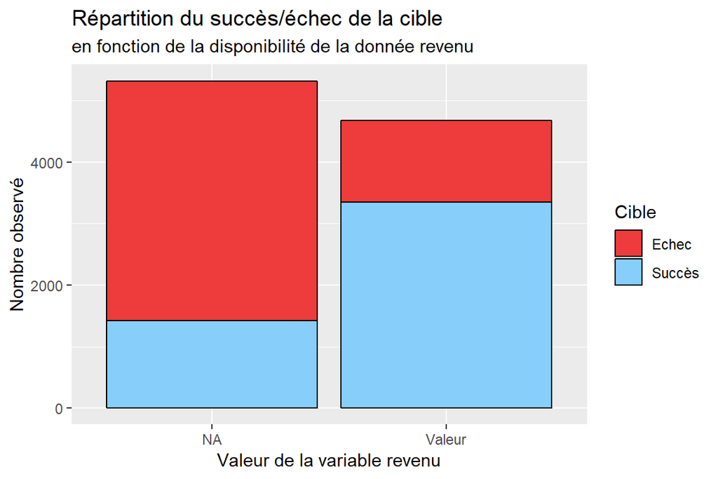

Graphiquement, nous voyons que la proportion d’échec de la campagne est plus importante lorsque la variable “revenu” n’est pas renseignée. Nous pouvons donc faire l’hypothèse qu’il y a un lien entre l’echec de la campagne et le fait d’avoir des revenus manquants.

### 2.2.3 Identifier la cause des revenus manquants et l’influence sur le résultat de la campagne

Composons une variable qui dépend de la disponibilité ou non (NA) de la variable revenu et du succès ou de l’échec de la campagne (variable cible). Cette nouvelle variable *revmv.cible* prend donc les valeurs :

| Variable Revenu | Cible = Succès | Cible = Echec |
| --- | --- | --- |
| Valeur numérique | **revVAL-succès** | **revVAL-échec** |
| NA | **revNA-succès** | **revNA-échec** |

Cherchons s’il se dégage une influence marquée, entre cette variable composée et une des covariables de notre jeu de données : l’age, la catégorie socio-professionnelle, le genre, la région ou le type de ville.

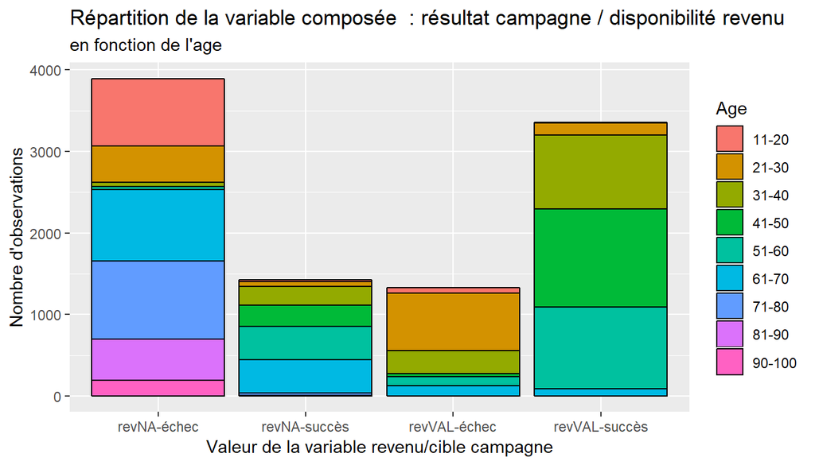

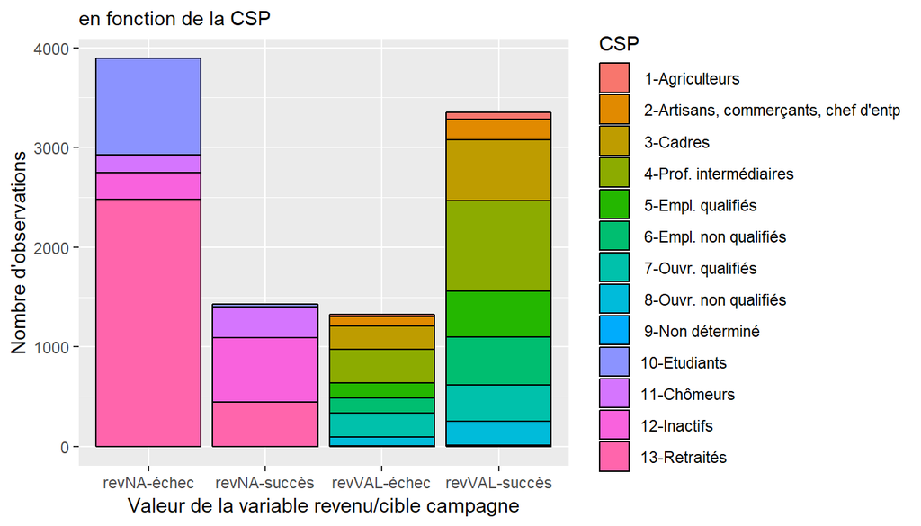

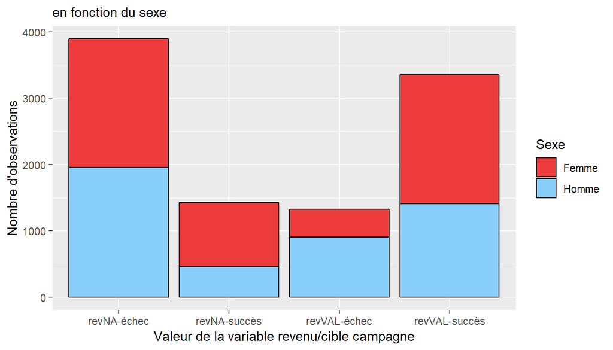

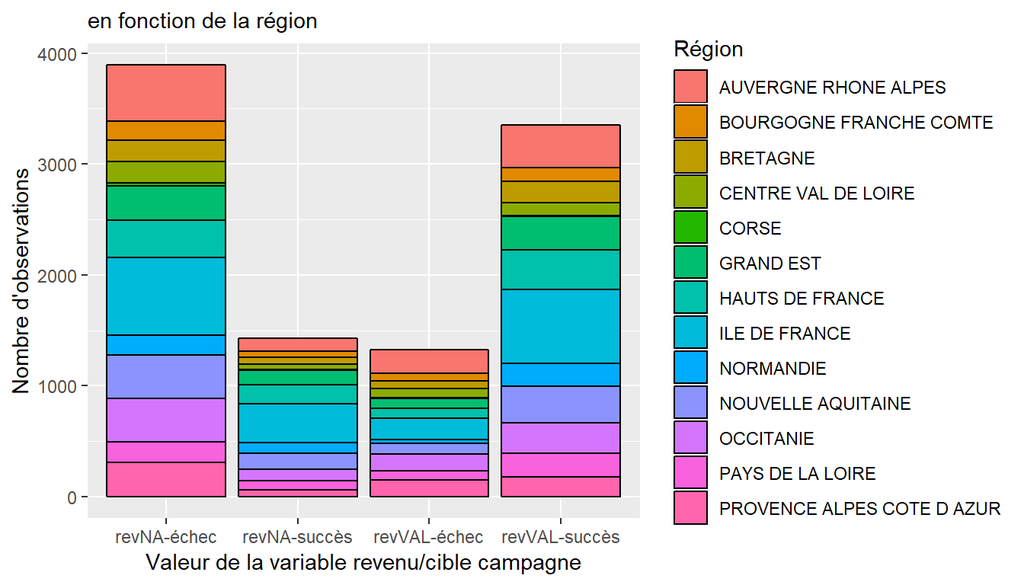

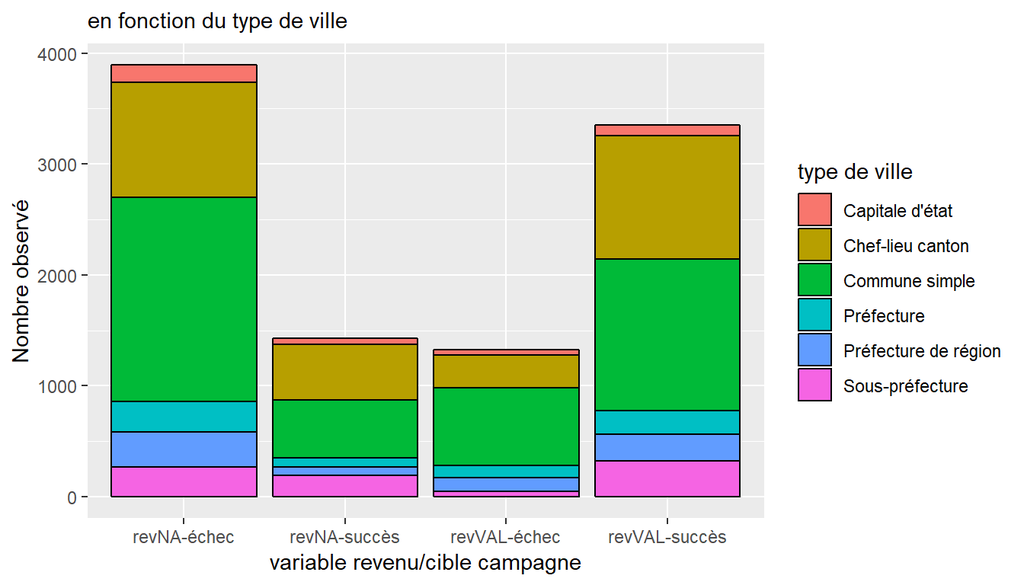

Il apparait que les valeurs du genre, de la région ou du type de ville sont représentées indifféremment que le revenu soit manquant ou non.

**L’âge** présente une particularité : les personnes de plus de 70 ans et, à forte majorité, celles de moins de 20 ans n’ont pas indiqué leur revenu et ne sont pas la cible de la campagne.

**La catégorie socio-professionnelle** est corrélée à l’absence d’indication de revenu. En effet, il apparait que les étudiants, les chômeurs, les inactifs et les retraités soient les seuls à ne pas avoir renseigné leur revenu.

**Les valeurs manquantes du revenu viennent donc exclusivement de 4 CSP , 10 Etudiants - 11 Chômeurs - 12 Inactifs et 13 Retraités, et concernent essentiellement les - de 20 ans et les + de 70 ans**

— Annexe—

Afin d’avoir plus d’informations sur les données manquantes, nous allons utiliser le graphique “Marginplot” et observé chaque variable avec la variable *revenue*. Dans ce graphique, les points sans valeurs manquantes apparaissent dans le scatterplot. On observe qu’il manque des valeurs pour tous les âges (ligne rouge verticale, de 15 à 100 ans). Nous avons également les boxplots des distributions des valeurs : en rouge quand la valeur est manquante et en bleu quand la valeur est observée.

**Le revenu et l’âge**

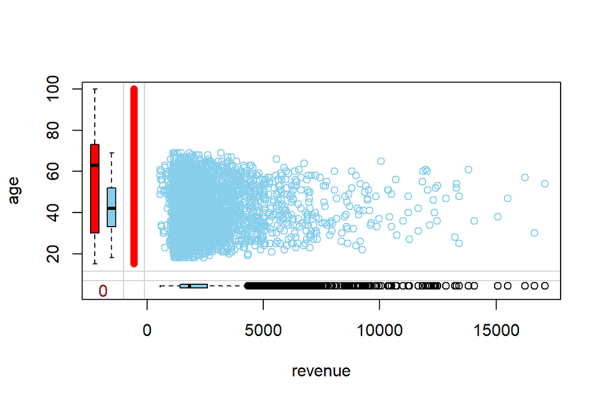

Les valeurs des revenus sont observées uniquement sur la tranche d’âge des 18 ans-69 ans, qui correspond à la période d’activité professionnelle.

**Le revenu et la catégorie socio-professionnelle**

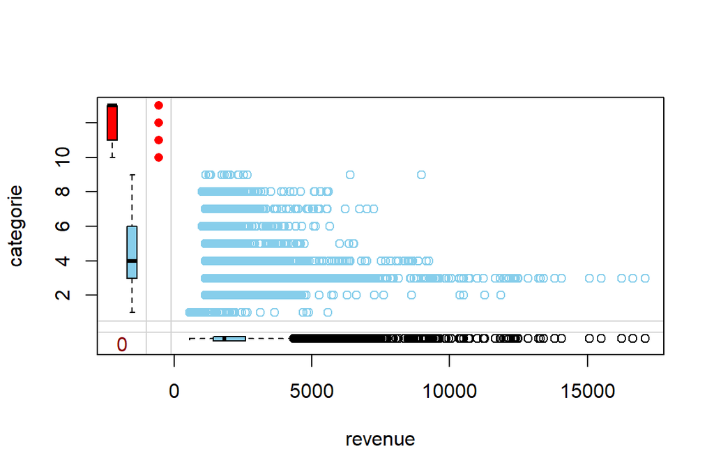

Dans la distribution on note que des personnes aux revenus se trouvent dans la catégorie cadres.

**Le revenu et le genre**

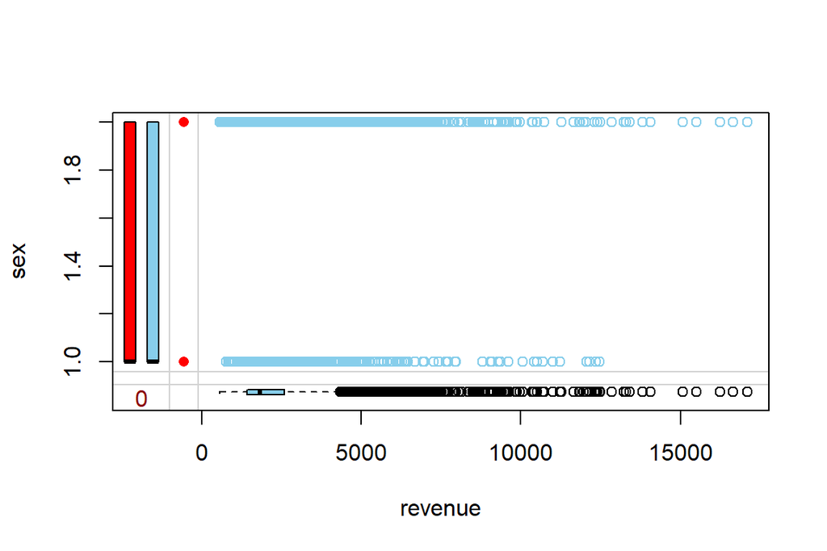

En ce qui concerne le genre, nous avons des données absentes pour les deux catégories, cependant les hommes ont les salaires le plus élevés de l’échantillon.

**Le revenu et la region**

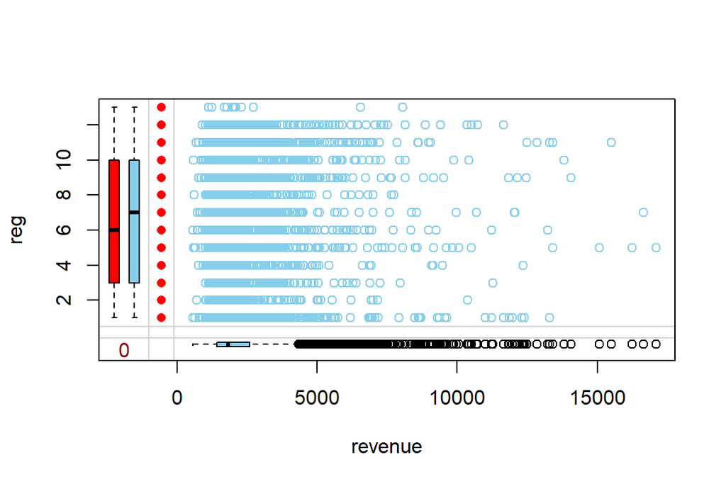

Pour la région aussi, il semblerait aussi que nous avons des données manquantes pour toutes les régions.

**Le revenu et le resultat de la campagne**

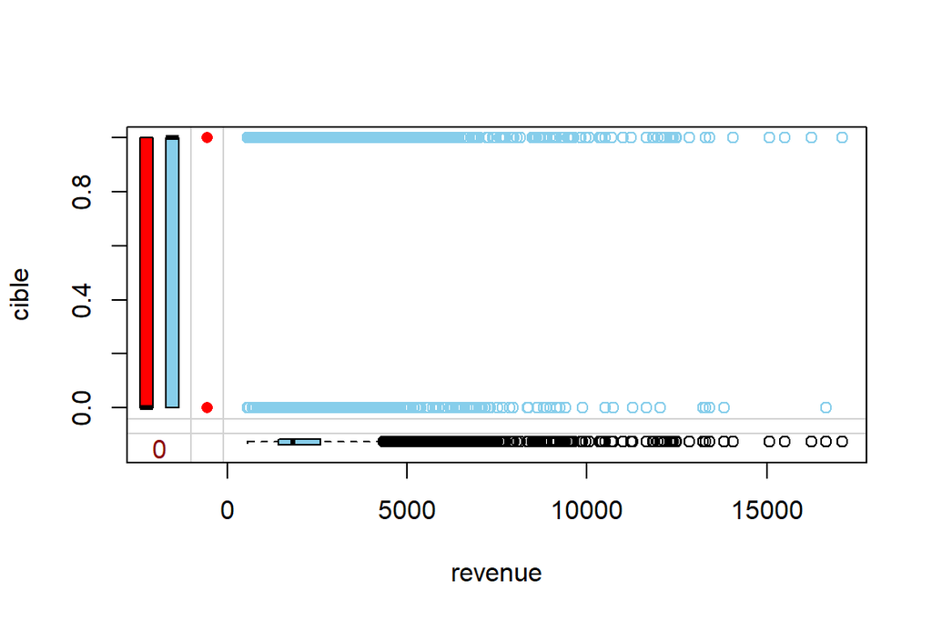

` Pour la cible, on observe qu’il y a des données manquantes pour les deux catégories : Failure et success. Mais leur absence n’est pas equilibrée, on retrouve plus des données absentes pour l’échec que pour le succès.

— fin annexe—

# 3 Analyse exploratoire des données

Regardons maintenant graphiquement les **principales particularités du jeu de données d’apprentissage.**

Sur l’ensemble de la population d’apprentissage :

- la majorité des individus, soit 5221, sont une **cible “échec” de la campagne, soit 52%** de cette population.*
- 4779 individus sont associés à une **campagne réussie, soit 48% de cette population.**

## 3.1 Résultat de la campagne selon le sexe des personnes interrogées

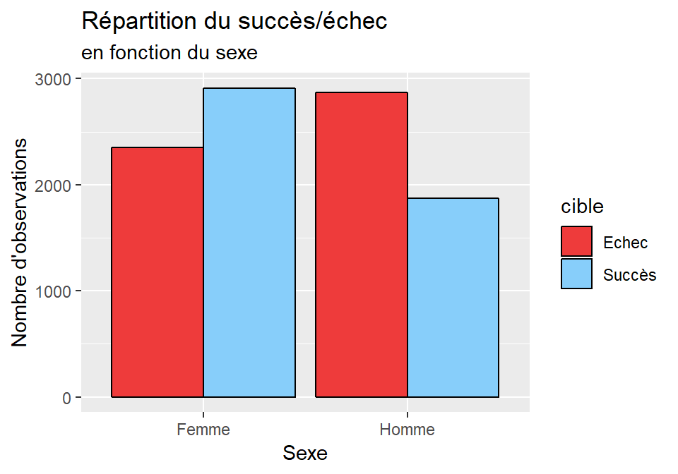

L’ensemble d’apprentissage comporte 5259 femmes (53% ) et 4741 hommes (47% ), soit un écart entre les femmes et les hommes supérieur à la situation nationale (la population globale française comprend 6% de plus de femmes seulement).

Le taux de réussite de la campagne chez les femmes de 55 % est plus important que chez les hommes 39 %.

**Les femmes ressortent donc majoritairement en réussite sur la cible de la campagne alors que les hommes sont à l’inverse majoritairement en échec.**

## 3.2 Résultat de la campagne selon l’age des personnes interrogées

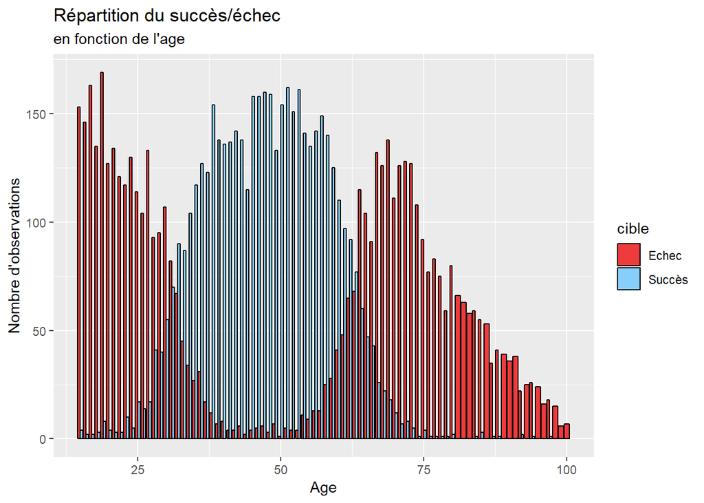

La courbe du nombre d’observations de réussite de la campagne forme une cloche entre 25 ans et 74 ans : pour les 40-55 ans, la campagne est quasi-totalement une réussite (haut de la cloche) ; alors que pour les populations les plus jeunes (avant 25 ans) et les plus agées (après 74 ans), l’échec sur la campagne est quasi-général.

**Le résultat de campagne est fortement déterminé par l’age de la personne interrogée**

## 3.3 Résultat de la campagne selon la catégorie socio-professionnelle des personnes interrogées

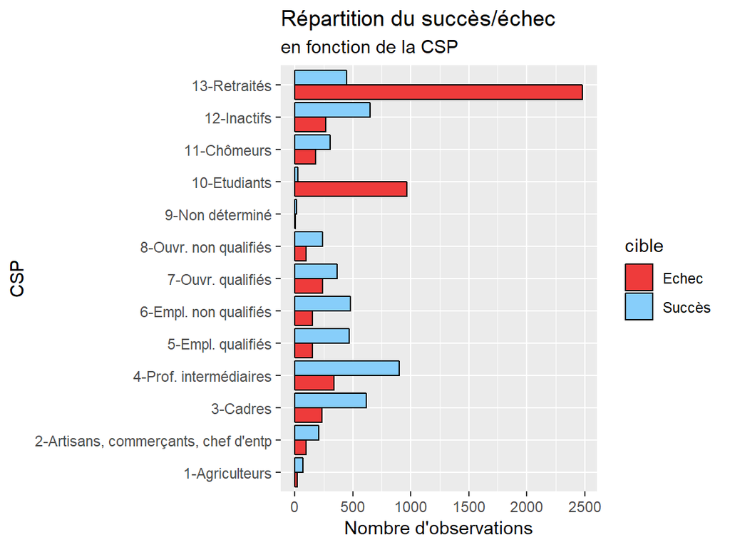

## 3.4 Résultat de la campagne selon le type de ville

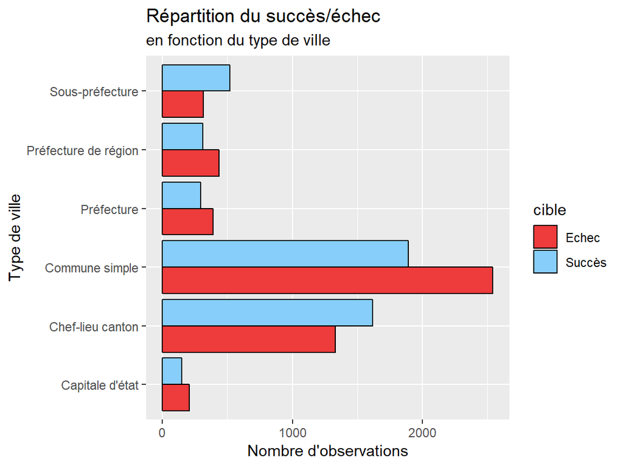

Le type de ville principalement interrogées sont les communes simples et les chefs lieu de canton (73% des réponses). Les échecs de la campagne sont majoritaires dans tous les types de ville sauf 2 : les sous-préfectures et les chefs-lieux de canton.

## 3.5 Résultat de la campagne selon les régions

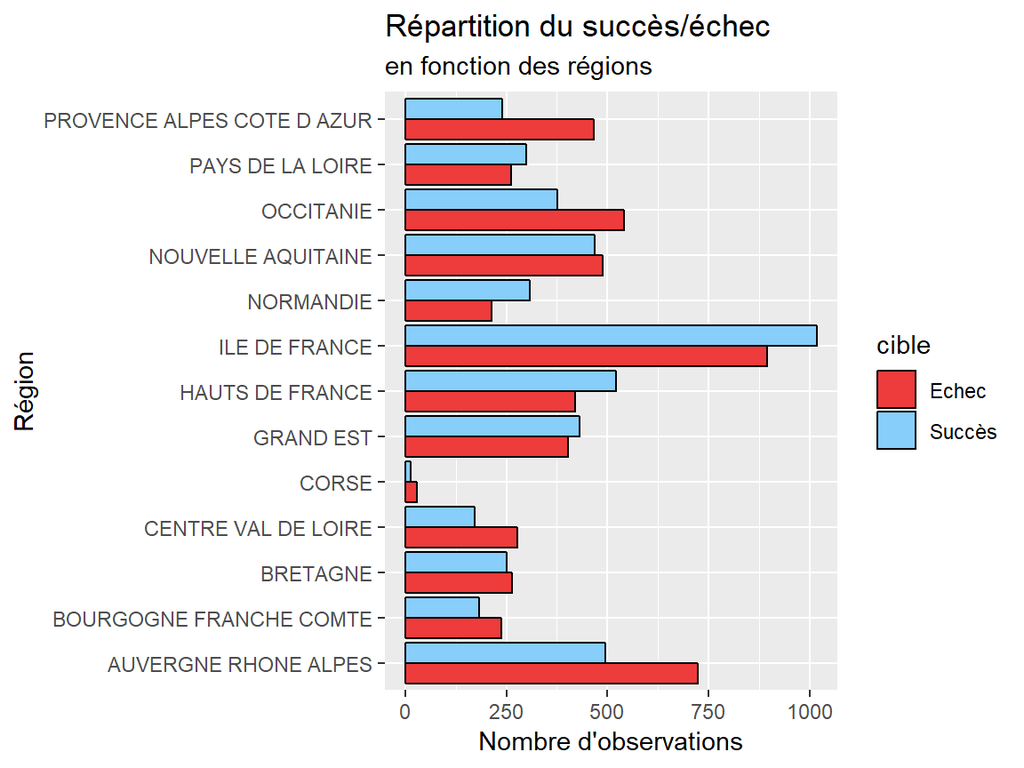

Les régions dans lesquelles le plus de personnes ont été interrogées sont l’Ile de France (où le succès l’emporte) et l’Auvergne Rhône Alpes (où l’échec l’emporte).

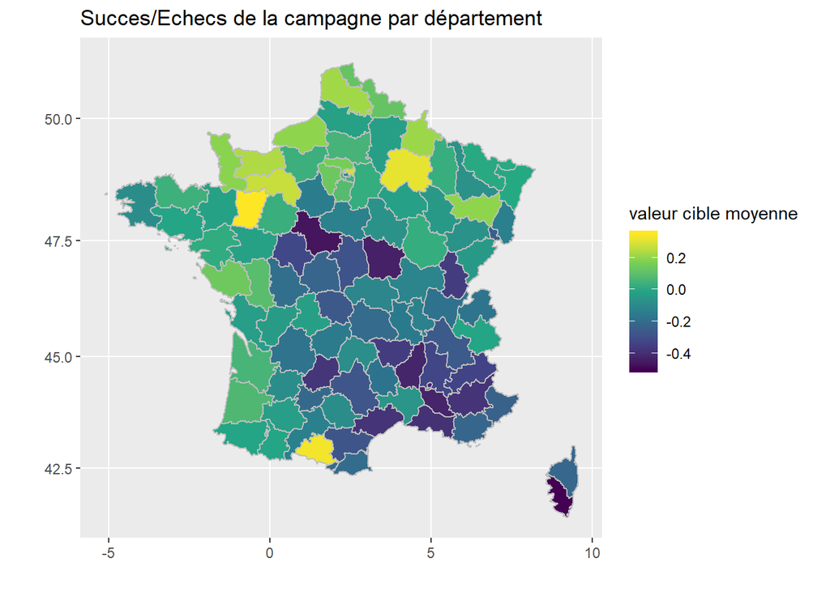

Sur cette carte, on a attribué la valeur “1” aux individus pour lesquels la campagne est un succès et la valeur “-1” en cas d’échec. La valeur cible moyenne est la moyenne des valeurs cible (1 et -1) sur l’ensemble des personnes interrogées du département.

On retrouve sur la carte **les zones de succès (valeur moyenne cible >0) au Nord et à l’Ouest ; et du centre au quart sud Est, les régions enregistent majoritairement des échecs.**  
(3 départements à fort succès : Mayenne, Ariège et Marne / 3 départements à fort échecs : Corse du Sud, Loire et Cher, Nièvre).

## 3.6 Récapitulatif de l’analyse exploratoire : caractéristiques des résultats de la campagne

| Succès = 48% : sont plutôt | Echec = 52% : sont plutôt |
| --- | --- |
| des femmes | des hommes |
| entre 40 et 55 ans | - de 25 ans ou + de 70 ans |
| professions intermédiaires, inactifs, cadres | étudiants, retraités |
| résidents du quart Nord-ouest | résidents du Centre au quart Sud-Est |

# 4 Ajustement des modèles

Il s’agit, d’une part, de construire le modèle de prédiction de la cible de campagne, en testant plusieurs méthodes (régression logistique, arbre de decision, random forests, boosting), d’évaluer les performances des modèles en calculant le taux d’erreur entre les prévisions et les vraies valeurs, en analysant la courbe de ROC. D’autre part, on tentera d’identifier les variables les plus influentes pour la détermination de la prédiction (importance des variables).

## 4.1 Régression logistique

**Validation croisée**

Nous créons d’abord la partition de données, avec 70% pour l’entrainement et 30% pour la validation.  
Nous excluons les variables de type identifiant et avec trop de modalités, pour éviter de bloquer les algorithmes (insee.code, f_name,last.name, commune, départment, latitude, longitude, X, Y, reg) et la variable revenu qui contient des valeurs manquantes.

Ensuite nous utilisons la fonction GLM, pour faire une régression logistique

```
##
## Call:
## glm(formula = cible ~ categorie + age + sex + city.type + REGION +
##     population, family = binomial(logit), data = train)
##
## Deviance Residuals:
##     Min       1Q   Median       3Q      Max
## -2.6923  -0.6071  -0.1236   0.6502   3.1905
##
## Coefficients:
##                                    Estimate Std. Error z value Pr(>|z|)
## (Intercept)                      -1.423e+00  4.465e-01  -3.187 0.001435
## categorie2                       -5.789e-01  3.915e-01  -1.479 0.139261
## categorie3                       -3.957e-01  3.748e-01  -1.056 0.291131
## categorie4                       -3.907e-01  3.705e-01  -1.054 0.291715
## categorie5                       -5.374e-01  3.826e-01  -1.405 0.160132
## categorie6                       -8.165e-01  3.823e-01  -2.135 0.032725
## categorie7                       -6.655e-01  3.762e-01  -1.769 0.076848
## categorie8                       -2.742e-01  3.941e-01  -0.696 0.486645
## categorie9                       -2.532e-01  9.232e-01  -0.274 0.783897
## categorie10                      -4.338e+00  4.365e-01  -9.939  < 2e-16
## categorie11                      -6.243e-01  3.826e-01  -1.632 0.102785
## categorie12                      -8.948e-01  3.729e-01  -2.399 0.016426
## categorie13                      -5.691e+00  3.832e-01 -14.850  < 2e-16
## age                               5.702e-02  2.962e-03  19.252  < 2e-16
## sexMale                          -1.348e+00  7.375e-02 -18.273  < 2e-16
## city.typeChef-lieu canton         1.163e+00  2.105e-01   5.522 3.35e-08
## city.typeCommune simple           5.007e-01  2.208e-01   2.267 0.023364
## city.typePréfecture               6.105e-01  2.281e-01   2.676 0.007444
## city.typePréfecture de région     2.771e-01  2.307e-01   1.201 0.229791
## city.typeSous-préfecture          2.055e+00  2.344e-01   8.769  < 2e-16
## REGIONBOURGOGNE FRANCHE COMTE     3.263e-01  1.837e-01   1.777 0.075648
## REGIONBRETAGNE                    3.511e-01  1.746e-01   2.011 0.044292
## REGIONCENTRE VAL DE LOIRE         8.664e-02  1.769e-01   0.490 0.624211
## REGIONCORSE                      -1.714e-01  4.958e-01  -0.346 0.729610
## REGIONGRAND EST                   8.475e-01  1.502e-01   5.643 1.67e-08
## REGIONHAUTS DE FRANCE             1.037e+00  1.444e-01   7.181 6.94e-13
## REGIONILE DE FRANCE               9.046e-01  1.285e-01   7.038 1.95e-12
## REGIONNORMANDIE                   1.350e+00  1.702e-01   7.930 2.19e-15
## REGIONNOUVELLE AQUITAINE          7.596e-01  1.396e-01   5.440 5.34e-08
```

[output cut: 33 more lines]

```
## REGIONNOUVELLE AQUITAINE         ***
## REGIONOCCITANIE
## REGIONPAYS DE LA LOIRE           ***
## REGIONPROVENCE ALPES COTE D AZUR ***
## population                       .
## ---
## Signif. codes:  0 '***' 0.001 '**' 0.01 '*' 0.05 '.' 0.1 ' ' 1
##
## (Dispersion parameter for binomial family taken to be 1)
##
##     Null deviance: 9691.8  on 7000  degrees of freedom
## Residual deviance: 5849.7  on 6968  degrees of freedom
## AIC: 5915.7
##
## Number of Fisher Scoring iterations: 6
```

**Prédiction**

Voici la matrice de confusion quand le seuil est fait à 50% :

```
##
##         FALSE TRUE
##   FALSE  1258  197
##   TRUE    308 1236
```

L’erreur de prédiction que nous obtenons est de :16.84 %

Nous pouvons optimiser cette prédiction, en trouvant le seuil optimal :49.17 %. La matrice de confusion devient :

[output not shown]

**Ajustement du modèle**

Graphique des résidus

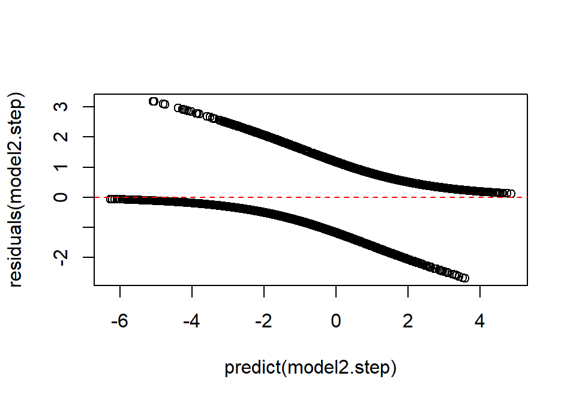

**Courbe de ROC** :

Comme dernière étape, nous allons construire la courbe ROC et calculer l’AUC (area under the curve), qui sont des mesures de performance : la courbe ROC est la représentation des TPR (True positive rate, “Vrais positifs”) en fonction des FPR (False positive rate, ’faux positifs), selon plusieurs seuils. La courbe de ROC doit être au-dessus de la première bissectrice. Plus la courbe ROC de l’algorithme tend vers 1 (100%) rapidement, meilleure est la qualité de la prédiction.

L’AUC est l’aire sous la courbe ROC. Elle doit être comprise entre 0.5 et 1 (seuil AUC donnant la meilleure qualité de la prédiction).

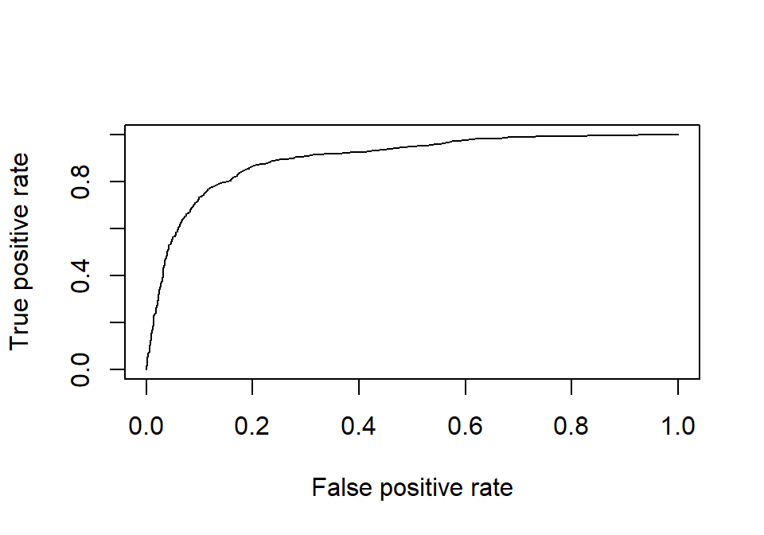

**Avec un modèle GLM, on obtient un AUC de 0.8962688.**

## 4.2 Arbres de décision

Nous utilisons la fonction **rpart** pour construire l’arbre de décision.

**Validation croisée**

Comme pour la régression logistique, nous allons faire nos partitions avec 70% pour l’entrainement et 30% pour la validation. Nous retirons aussi ici les variables de type identifiant et avec trop de modalités, pour éviter de bloquer les algorithmes :insee.code,f_name,last.name,commune, department, latitude, longitude,X,Y,reg.

**Création du premier arbre**

Nous allons faire notre premier arbre sans ajuster les paramêtres de contrôle de l’arbre, avec les paramètres par défaut de la fonction rpart (minsplit = 20, minbucket = round(minsplit/3), cp = 0.01)

Voici le graphique de l’arbre qui est produit avec rpart:

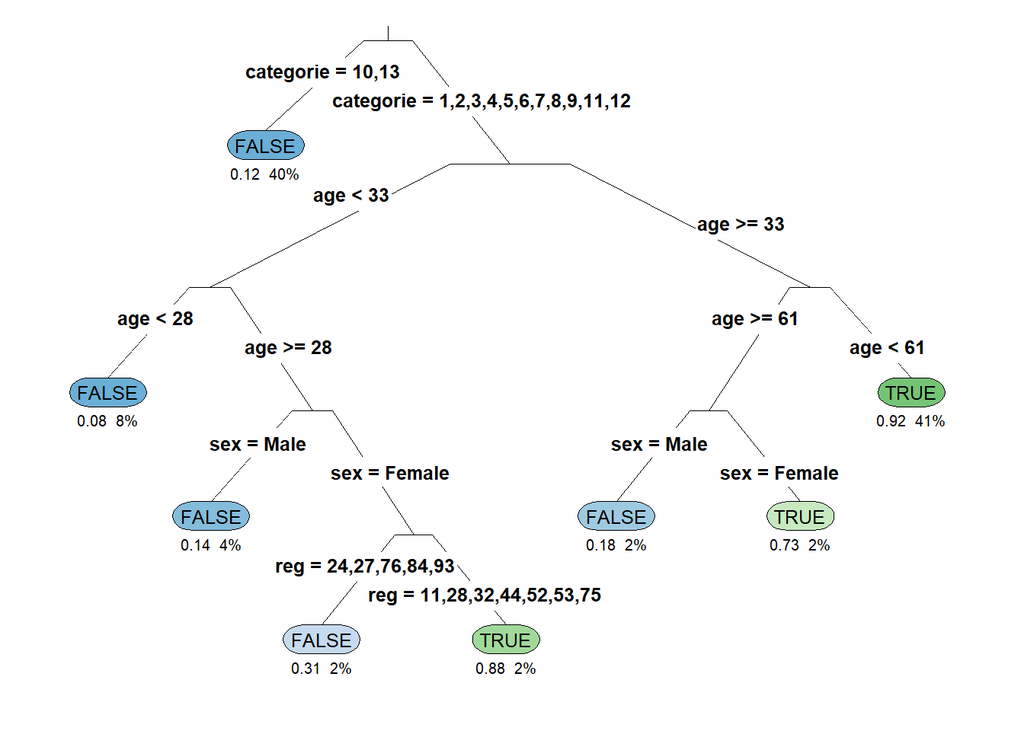

**rpart** utilise l’impureté Gini pour sélectionner les divisions lors de la classification. L’impureté Gini est la probabilité de classer incorrectement un élément choisi au hasard dans l’ensemble de données, s’il était étiqueté de manière aléatoire en fonction de la distribution des classes. Si l’impureté Gini est à 0 , cela signifie que les données sont dans la même classe.

Avec ce graphique, chaque noeud montre :

- La classe prédite (TRUE ou FALSE)
- La probabilité d’être VRAI
- Pourcentage d’observations dans chaque noeud

**Zoom sur le CP**

Le CP (complexity parameter) est utilisé pour contrôler la croissance de l’arbre et sélectionner la taille optimale de l’arbre. Si le coût d’ajouter une variable est plus élevé que la valeur du CP, la croissance s’arrête.

Les fonctions **printcp** et **plotcp** fournissent l’erreur de validation croisée pour chaque nsplit et peuvent être utilisées pour élaguer l’arbre. Celui avec le moins d’erreur de validation croisée (xerror) est la valeur optimale de CP.

Avec plotcp, il vous montre également l’endroit optimal pour élaguer l’arbre. Un bon choix de CP pour l’élagage est souvent la valeur la plus à gauche pour laquelle la moyenne se situe en dessous de la ligne horizontale, dans notre cas 0,01, la valeur par défaut.

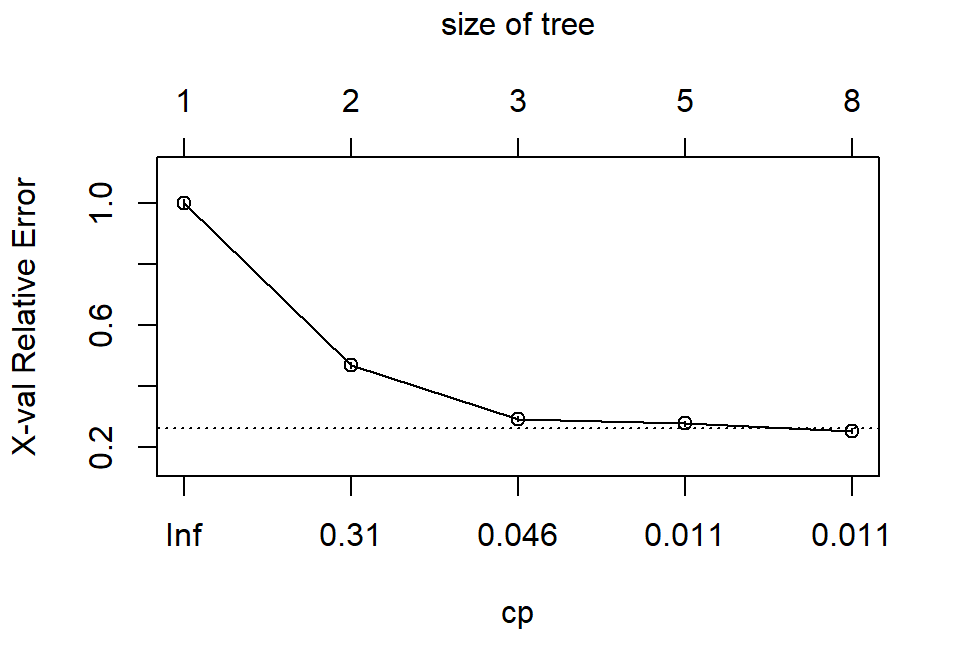

Pour la fonction **printcp**, chaque ligne représente une hauteur différente de l’arbre. En général, plus de niveaux dans l’arbre signifient qu’il a moins d’erreur de classification sur l’entrainement. Cependant, il existe le risque d’overfitting. Souvent, l’erreur de validation croisée augmentera à mesure que l’arbre atteindra plus de niveaux (au moins, après le niveau «optimal»).

```
##
## Classification tree:
## rpart(formula = cible ~ ., data = train_arbre, method = "class")
##
## Variables actually used in tree construction:
## [1] age       categorie reg       sex
##
## Root node error: 3346/7001 = 0.47793
##
## n= 7001
##
##         CP nsplit rel error  xerror      xstd
## 1 0.530185      0   1.00000 1.00000 0.0124911
## 2 0.179916      1   0.46981 0.46981 0.0104347
## 3 0.011955      2   0.28990 0.29378 0.0086875
## 4 0.011058      4   0.26599 0.27824 0.0084911
## 5 0.010000      7   0.23192 0.25344 0.0081590
```

sans surprise la meilleure valeur de cp est 0,01

**Matrice de confusion et ROC**

```
##
## tree.pred FALSE TRUE
##     FALSE  1417  191
##     TRUE    149 1242
```

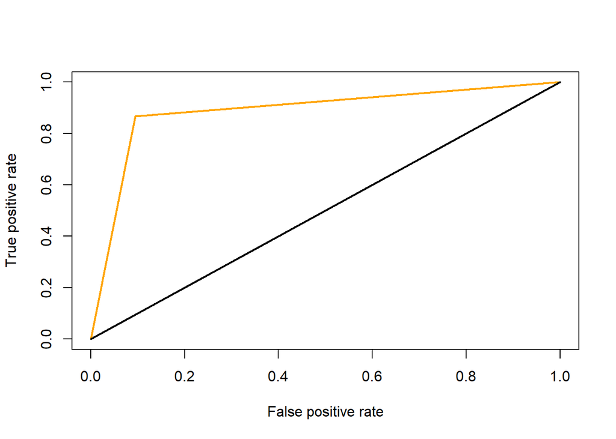

**Avec un modèle d’arbre de décision, on obtient un AUC est de 0.8857832**

**Tuner l’arbre**

Nous allons aussi modifier le paramètre “minsplit”, il contrôle le nombre minimum d’observations qui doit exister dans un nœud pour qu’une tentative de division soit faite, minbucket et CP

Nous allons démarrer avec le CP = 0.0001, et minsplit =2

[figure not shown]

## 4.3 Méthode ensembliste : Random Forest

La méthode repose sur l’apprentissage du modèle prédiction sur plusieurs arbres. Les différentes prédictions sont comparées selon leur qualité et une seule d’entre elles est retenue par vote majoritaire.  
La fonction utilisée est **randomForest**.

Nous reprenons les ensembles d’entrainement et de validation déjà utilisés pour les arbres de décision.

**Paramètres optimaux de la forêt aléatoire**

Les parametres d’une foret aléatoire sont le nombre d’arbres (ntree) et le nombre de variables explicatives testées à chaque séparation (mtry). Pour les optimiser, il faut chercher le modèle de forest aléatoire qui minimise l’erreur Out Of Bag.

Nous commençons par ne pas fixer ces paramètres.

La forêt aléatoire choisie de façon standard contient 500 arbres et teste 2 variables à chaque séparation.

```
##
## Call:
##  randomForest(formula = cible ~ ., data = train_arbre, na.action = na.omit)
##                Type of random forest: classification
##                      Number of trees: 500
## No. of variables tried at each split: 2
##
##         OOB estimate of  error rate: 7.14%
## Confusion matrix:
##     0    1 class.error
## 0 740  172  0.18859649
## 1  59 2265  0.02538726
```

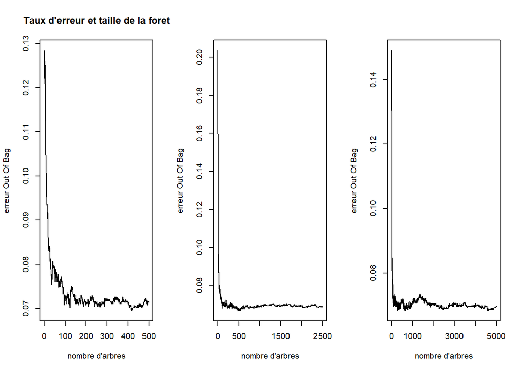

| Nombre d’arbres (ntree) | taux d’erreur Out of Bag |
| --- | --- |
| 500 | 7.14 |
| 2500 | 6.86 |
| 3500 | 6.89 |
| 5000 | 6.95 |

Après avoir fixé le nombre d’arbre à 5000, essayons d’approcher maintenant le nombre de variables explicatives testées à chaque séparation (mtry) optimum. Nous testons mtry = 1 , 4 et 6 . Il apparait que le taux d’erreur est le plus bas pour mtry=4.

| Nombre de var. (mtry ) | taux d’erreur Out of Bag |
| --- | --- |
| 1 | 11.37 |
| 2 | 6.95 |
| 4 | 6.27 |
| 6 | 6.8 |

```
##
## Call:
##  randomForest(formula = cible ~ ., data = train_arbre, ntree = 5000,      mtry = 4, na.action = na.omit)
##                Type of random forest: classification
##                      Number of trees: 5000
## No. of variables tried at each split: 4
##
##         OOB estimate of  error rate: 6.27%
## Confusion matrix:
##     0    1 class.error
## 0 773  139  0.15241228
## 1  64 2260  0.02753873
```

**Importance des variables**

L’importance des variables explicatives selon le critère de Gini : plus le critère est haut, plus la variable aura de l’influence pour distinguer le succès de l’echec de la campagne . Ici l’age est la variable la plus discriminante.

```
##        age        reg        sex    revenue population  city.type
##  798.25560  126.32252   90.78005   83.93898   81.85332   76.30303
##  categorie
##   51.59120
```

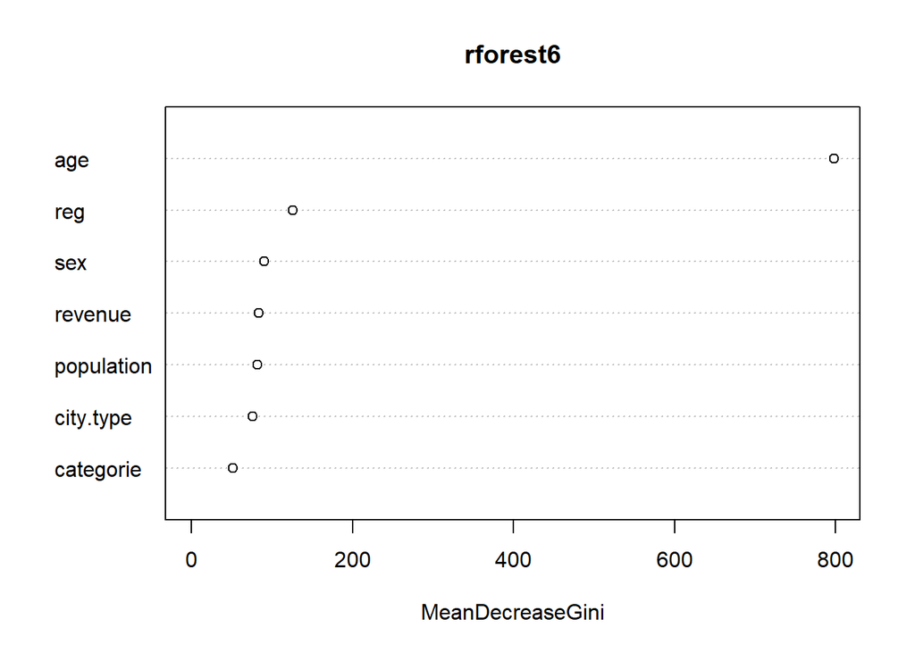

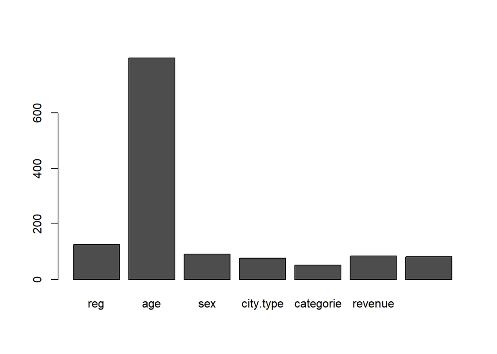

**Prediction à partir d’un modèle ramdom forest**

```
##
## rforest6.pred    0    1
##             0  341   24
##             1   74 1005
```

[figure not shown]

```
## [1] 0.8991816
```

**Avec un modèle de forêt aléatoire, on obtient un AUC est de 0.8991816**

# 5 Annexes

## 5.1 ANNEXE - Imputation des données

Pour que l’imputation fonctionne, il faut enlever des colonnes avec trop de catégories, et celles qui ne devraient pas apporter plus d’information comme le prénom et le nom.

L’imputation avec mice, sera faite avec rf : “Random forest imputation”, en utilisant les données d’age, sex, region, categorie et population pour trouver le revenue correspondant.

## 5.2 ANNEXE - Analyse exploratoire

Les resultats semblent bien équilibrées entre les deux catégories à prédire : Echec et Succès

Nous observons une distribution très différente selon l’âge : l’échec est bien répartie entre 25 et 75 ans, par contre le succès est concentré entre 30 et 55 ans, avec quelques valeurs extrêmes superieurs à 75 ans. L’âge est sûrement une variable qui sera pertinente pour la prédiction.

Pour la population et les revenus, il ne semble pas y avoir des différences.

Les retraités et les étudiants (catégorie 13 et 10), enregistrent la plupart des échecs, tandis que les catégories 2 a 8, 11 et 12 (chomeurs et inactifs) ont la plupart des succès, surement s’agit-il d’une des variables à garder pour la prédiction.

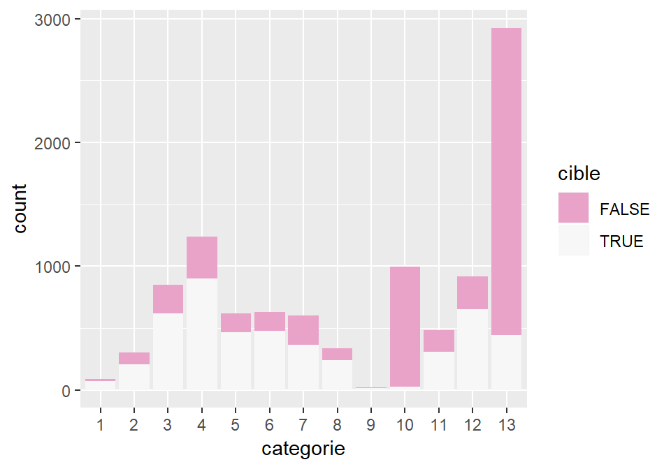

```
##
##      FALSE TRUE
##   1     19   68
##   2     97  205
##   3    233  617
##   4    338  901
##   5    154  466
##   6    149  478
##   7    237  366
##   8     96  239
##   9      4   13
##   10   968   26
##   11   180  305
##   12   266  651
##   13  2480  444
```

Paris, en tant que capitale, enregistre très peu de résultats, en sachant que la région Ile de France est la plus représentée dans l’échantillon.

Les âges sont bien repartis sur tous les types de communes.

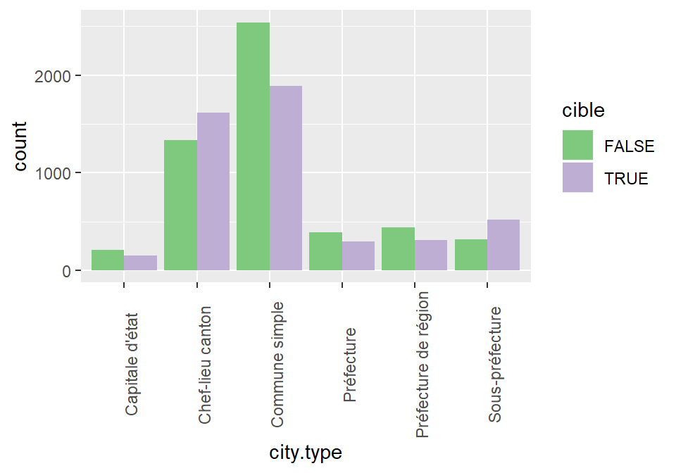

```
##
##                        FALSE TRUE
##   Capitale d'état        206  148
##   Chef-lieu canton      1331 1615
##   Commune simple        2541 1890
##   Préfecture             389  293
##   Préfecture de région   437  312
##   Sous-préfecture        317  521
```

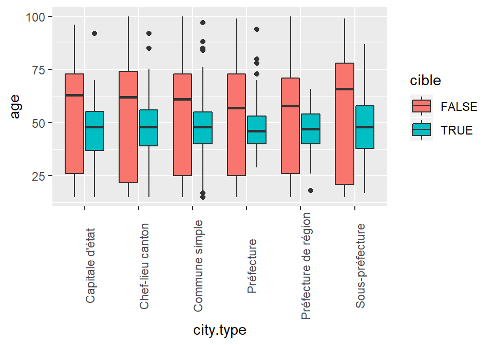

Voici la repartition des reponses sur toute la France, on observe plus de succès au nord et plus d’échecs au sud (region Auvergne-Rhône-Alpes).

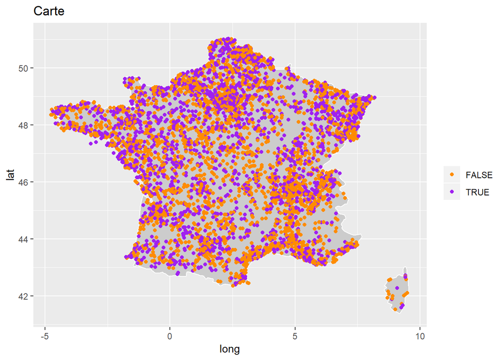

Ce graphique montre que les variables qui vont beaucoup influencer notre prédiction seront surement l’age et la categorie socio-professionnelle.

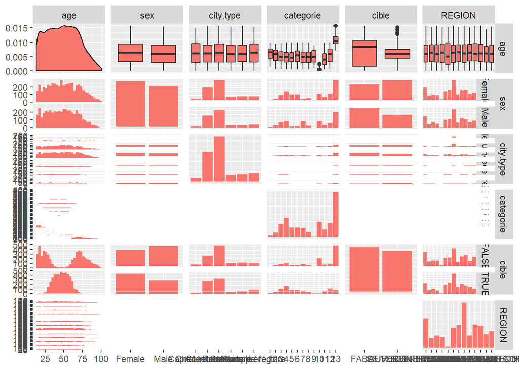

## 5.3 ANNEXE - Ajustement des modèles

**Random forest à 5000 arbres**